# Project Name: Preliminary version of Turtle Trading Strategy

Date: 28 Sep 2023

Three portfolio analysis reports have been generated in HTML format within the 'outcome' folder

Turtle strategy is one of classic trend-following system that has clear defined trading rules. The system was taught by Richard Dennis and William Eckhardt in 1983. This version implements the system described by Curtis Faith, author of bestselling book Way of the Turtle.

This Python module attempts to implement the system on backtrader framework as described in the pdf by Curtis Faith & Perry J. Kaufman.

```python
from datetime import datetime,timedelta
import backtrader as bt
import pandas as pd
import numpy as np
import matplotlib.pyplot as plt
import yfinance as yf
import quantstats
```

## This module is designed for Turtle Trading Strategy

1. Entry condition: When the product price surpasses the highest point within the last 20 days (Price at T+1 opening).
2. Exit condition: When the product price falls below the lowest point within the last 10 days (Price at T closing).
3. Risk for any given trade should not exceed 2% of the account's net assets.
4. Increase position by 1/2 ATR of the corresponding product (position size can be self-adjusted).

### The following recommendations will enhance this module:

```
- Refine profit related ratio like cumulative daily returns;
- Utilize an indicator to display trade directions and corresponding numbers;
```

*In Financial View*

```
- Add test interval to decide the long period and short_period
- Set stop loss position
- More Risk management like limit initiate position
```

```python
class TurtleStrategy(bt.Strategy):
    params = (('long_period',20),
              ('short_period',10),
              ('printlog', False), )

    def __init__(self):
        self.order = None
        self.buyprice = 0
        self.buycomm = 0
        self.buy_size = 0
        self.buy_count = 0

        # Donchian and ATR
        self.H_line = bt.indicators.Highest(self.data.high(-1), period=self.p.long_period)
        self.L_line = bt.indicators.Lowest(self.data.low(-1), period=self.p.short_period)
        self.M_line = (self.H_line+self.L_line)/2
        self.TR = bt.indicators.TrueRange(self.data)
        self.ATR = bt.indicators.SimpleMovingAverage(self.TR,period=self.p.long_period)
        # Signal
        self.buy_signal = bt.ind.CrossOver(self.data.close(0), self.H_line)
        self.sell_signal = bt.ind.CrossOver(self.data.close(0), self.L_line)

    def next(self):
        if self.order:
            return

        # Entry condition
        if self.buy_signal > 0 and self.buy_count == 0:
            self.buy_size = self.broker.getvalue() * 0.01 / self.ATR
            self.buy_size  = int(self.buy_size / 100) * 100
            self.sizer.p.stake = self.buy_size
            self.buy_count = 1
            self.order = self.buy()

        # Exit condition
        elif self.sell_signal < 0 and self.buy_count > 0:
            self.order = self.sell()
            self.buy_count = 0

        # Increase position by 1/2 ATR of the corresponding product & No more than 4 times
        elif self.data.close >self.buyprice+0.5*self.ATR[0] and self.buy_count > 0 and self.buy_count <=4:
            self.buy_size  = self.broker.getvalue() * 0.01 / self.ATR
            self.buy_size  = int(self.buy_size  / 100) * 100
            self.sizer.p.stake = self.buy_size
            self.order = self.buy()
            self.buy_count += 1

        # Risk Management
        size = (self.broker.getvalue() * 0.01) / self.ATR[0]
        total_risk = size * self.ATR[0]

        # Do not risk more than 2% of account equity on a single trade.
        if total_risk > (self.broker.getvalue() * 0.02):
            return


    # Order Log
    def log(self, txt, dt=None,doprint=False):
        if self.params.printlog or doprint:
            dt = dt or self.datas[0].datetime.date(0)
            print(f'{dt.isoformat()},{txt}')

    # Order Status
    def notify_order(self, order):
        if order.status in [order.Submitted, order.Accepted]:
            return
        if order.status in [order.Completed]:
            if order.isbuy():
                self.log(f'BUY EXECUTED\nPrice At:{order.executed.price},\
                Cost:{order.executed.value},\
                Commission:{order.executed.comm}')
                self.buyprice = order.executed.price
                self.buycomm = order.executed.comm
            else:
                self.log(f'SELL EXECUTED\nPrice At：{order.executed.price},\
                Cost: {order.executed.value},\
                Commission:{order.executed.comm}')
            self.bar_executed = len(self)
        # IF cancel/ reject order
        elif order.status in [order.Canceled, order.Margin, order.Rejected]:
            self.log('Order Canceled/Margin/Rejected')
        self.order = None

    # Trade
    def notify_trade(self,trade):
        if not trade.isclosed:
            return

        self.log(f'Strategy Return：\nGross Profit {trade.pnl:.2f}, Net Profit {trade.pnlcomm:.2f}')

    def stop(self):
        self.log(f'(Period：{self.p.long_period},{self.p.short_period})； \
        Final Portfolio Value: {self.broker.getvalue():.2f}', doprint=False)
```

## This module is designed for backtesting based on yahoo finance.

AUDNZD TICKER : AUDNZD=X

With conditions:  
1.Test Portfolio (Products): AUDNZD 2.Trading Commission: 0.0002% of the transaction amount  
3.Test Duration: July 1, 2020, to July 1, 2023  
4.Initial Test Capital: $1,000,000 USD

Three portfolio analysis reports have been generated in HTML format within the 'outcome' folder.  
Given limited space in Jupter Notebook, HTML files offer improved visualization.

```
[*********************100%%**********************]  1 of 1 completed
Starting Portfolio Value: 1000000.00
Final Portfolio Value: 1019651.41
```

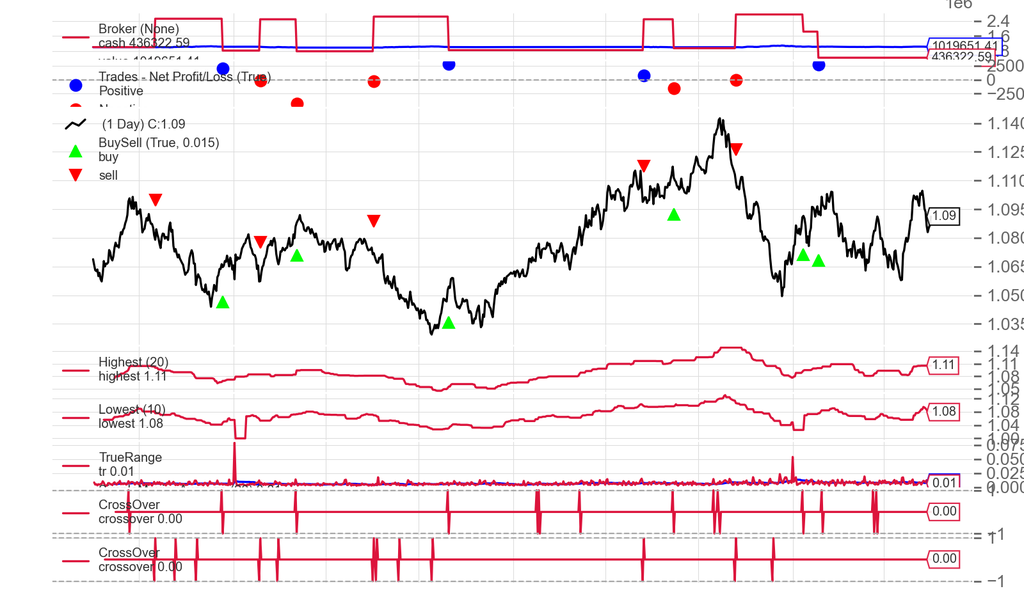

```python
def run_backtest():
    cerebro = bt.Cerebro()

    data = yf.download("AUDNZD=X",'2020-07-01','2023-07-01')
    datafeed = bt.feeds.PandasData(dataname=data)
    cerebro.adddata(datafeed)

    cerebro.addstrategy(TurtleStrategy)
    cerebro.broker.setcash(1000000.0)
    cerebro.broker.setcommission(commission=0.000002)

    print('Starting Portfolio Value: %.2f' % cerebro.broker.getvalue())
    cerebro.addanalyzer(bt.analyzers.PyFolio, _name='PyFolio')
    results = cerebro.run()
    strat = results[0]
    print('Final Portfolio Value: %.2f' % cerebro.broker.getvalue())
    cerebro.plot()

###### The HTML preview on the laptop is too slow to generate, so please refer to the backtest plot in Jupter Notebook.
###### For additional information, consult the HTML files in 'outcome' folder.

    # Analyze in HTML
#     portfolio_stats = strat.analyzers.getbyname('PyFolio')
#     returns, positions, transactions, gross_lev = portfolio_stats.get_pf_items()
#     returns.index = returns.index.tz_convert(None)
#     quantstats.reports.html(returns, output='AUDNZD.html', title='AUDNZD=X Sentiment')


if __name__ == '__main__':
    run_backtest()
```